# EXPLORACIÓN INICIAL Y AUDITORÍA DE CALIDAD

## Objetivo:

**Cargar los datos y realizar una auditoría completa de calidad.**

### Justificación:

La fase de Data Understanding incluye “describir los datos en detalle” y “verificar la calidad de los datos”. “Los datos deben entenderse en su totalidad antes de la fase de preprocesamiento”

## Ejecutar la auditoría de calidad:

- Resumen de calidad por columna (tipo, faltantes, % faltantes, valores únicos).
- Visualización de valores faltantes.
- Validación de rangos numéricos.
- Detección de outliers mediante IQR.

```
Descargando dataset desde Kaggle...
Dataset descargado en: C:\Users\Divios\.cache\kagglehub\datasets\bhaskerpaul\sales-and-marketing-dataset\versions\1

--- Archivos disponibles ---
 - Sales - Marketing customer dataset.csv

Usando archivo esperado: Sales - Marketing customer dataset.csv
Archivo seleccionado: C:\Users\Divios\.cache\kagglehub\datasets\bhaskerpaul\sales-and-marketing-dataset\versions\1\Sales - Marketing customer dataset.csv

Cargando archivo...
✅ Archivo cargado: 15,000 filas, 30 columnas
✅ Nombres de columnas estandarizados
ℹ️ El archivo ya existe en c:\Users\Divios\Desktop\MEACD_ML1\S1\sales-marketing-churn-analysis\data\raw\sales_marketing_raw.csv

================================================================================
 AUDITORÍA DE CALIDAD DE DATOS
================================================================================

--- RESUMEN DE CALIDAD POR COLUMNA ---
                               tipo  faltantes  porcentaje_faltantes  \
coupon_code                  object       6133                 40.89
age                         float64       1200                  8.00
total_spent                 float64       1050                  7.00
gender                       object        738                  4.92
satisfaction_score          float64        702                  4.68
customer_id                   int64          0                  0.00
avg_session_time            float64          0                  0.00
pages_per_session           float64          0                  0.00
avg_order_value             float64          0                  0.00
lifetime_value              float64          0                  0.00
marketing_spend_per_user    float64          0                  0.00
signup_date                  object          0                  0.00
last_purchase_date           object          0                  0.00
email_open_rate             float64          0                  0.00
email_click_rate            float64          0                  0.00
total_visits                  int64          0                  0.00
last_3_month_purchase_freq    int64          0                  0.00
delivery_delay_days           int64          0                  0.00
nps_score                     int64          0                  0.00
support_tickets               int64          0                  0.00
```

[output cut: 35 more lines]

```
payment_method                           5
device_type                              3
subscription_type                        2
is_premium_user                          2
discount_used                            2
refund_requested                         2
churn                                    2

--- VALORES FALTANTES ---
                    porcentaje_faltantes
coupon_code                    40.886667
age                             8.000000
total_spent                     7.000000
gender                          4.920000
satisfaction_score              4.680000
```

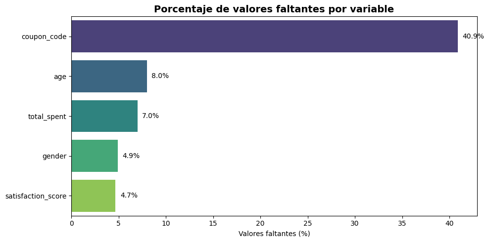

```
--- RANGOS DE VARIABLES NUMÉRICAS ---
                              count      mean      std       min       25%  \
customer_id                 15000.0  17500.50  4330.27  10001.00  13750.75
age                         13800.0     35.20    10.33     -4.00     28.00
is_premium_user             15000.0      0.30     0.46      0.00      0.00
total_visits                15000.0     15.00     3.89      3.00     12.00
avg_session_time            15000.0      8.02     2.99      0.01      5.97
pages_per_session           15000.0      4.00     1.48      0.01      2.99
email_open_rate             15000.0      0.50     0.29      0.00      0.24
email_click_rate            15000.0      0.25     0.14      0.00      0.13
total_spent                 13950.0    524.36   467.05      0.27    300.43
avg_order_value             15000.0     60.08    24.75      0.07     43.03
discount_used               15000.0      0.49     0.50      0.00      0.00
support_tickets             15000.0      2.00     1.42      0.00      1.00
refund_requested            15000.0      0.15     0.35      0.00      0.00
delivery_delay_days         15000.0      2.98     1.72      0.00      2.00
satisfaction_score          14298.0      3.59     1.09      1.00      3.00
nps_score                   15000.0      4.97     3.16      0.00      2.00
marketing_spend_per_user    15000.0     17.58     7.18      5.00     11.38
lifetime_value              15000.0   1235.70   657.52      0.37    741.30
last_3_month_purchase_freq  15000.0      6.98     4.32      0.00      3.00
churn                       15000.0      0.15     0.36      0.00      0.00

                                 50%       75%       max     rango
customer_id                 17500.50  21250.25  25000.00  14999.00
age                            35.00     42.00     95.00     99.00
is_premium_user                 0.00      1.00      1.00      1.00
total_visits                   15.00     18.00     31.00     28.00
avg_session_time                7.99     10.06     19.12     19.12
pages_per_session               4.00      5.01     10.84     10.84
email_open_rate                 0.50      0.75      1.00      1.00
email_click_rate                0.25      0.38      0.50      0.50
total_spent                   498.84    702.40  15910.43  15910.16
avg_order_value                60.11     76.89    154.55    154.48
discount_used                   0.00      1.00      1.00      1.00
support_tickets                 2.00      3.00      9.00      9.00
refund_requested                0.00      0.00      1.00      1.00
delivery_delay_days             3.00      4.00     11.00     11.00
satisfaction_score              4.00      4.00      5.00      4.00
nps_score                       5.00      8.00     10.00     10.00
marketing_spend_per_user       17.63     23.77     30.00     25.00
lifetime_value               1216.21   1677.86   3767.49   3767.12
last_3_month_purchase_freq      7.00     11.00     14.00     14.00
churn                           0.00      0.00      1.00      1.00

--- DETECCIÓN DE OUTLIERS (IQR) ---
           variable  outliers  porcentaje
              churn      2298       15.32
   refund_requested      2215       14.77
 satisfaction_score       753        5.02
delivery_delay_days       184        1.23
                age        89        0.59
    support_tickets        79        0.53
        total_spent        78        0.52
     lifetime_value        56        0.37
    avg_order_value        54        0.36
   avg_session_time        45        0.30
       total_visits        39        0.26
  pages_per_session        33        0.22
```

```python
# ============================================================
# PASOS 1-4: CARGA Y AUDITORÍA DE CALIDAD (UNIVERSAL)
# ============================================================

import warnings
warnings.filterwarnings('ignore')

import os
import sys
sys.path.append(os.path.abspath('..'))

import pandas as pd
import numpy as np
import matplotlib.pyplot as plt
import seaborn as sns
import kagglehub

# Importar config completo
from src import config

# También importar variables específicas si las usas directamente
from src.config import (
    KAGGLE_DATASET, EXPECTED_FILENAME, ENCODING, SEPARATOR,
    CHUNK_SIZE, SAMPLE_ROWS, AUTO_CONVERT_DATES, AUTO_CLEAN_CURRENCY,
    RANDOM_STATE
)

# ============================================================
# 1.1 DESCARGA Y SELECCIÓN DEL ARCHIVO
# ============================================================

print("Descargando dataset desde Kaggle...")
path = kagglehub.dataset_download(KAGGLE_DATASET)
print(f"Dataset descargado en: {path}")

all_files = []
for dirname, _, filenames in os.walk(path):
    for filename in filenames:
        all_files.append(os.path.join(dirname, filename))

print("\n--- Archivos disponibles ---")
for f in all_files:
    print(f" - {os.path.basename(f)}")

if EXPECTED_FILENAME and EXPECTED_FILENAME in [os.path.basename(f) for f in all_files]:
    file_path = os.path.join(path, EXPECTED_FILENAME)
    print(f"\nUsando archivo esperado: {EXPECTED_FILENAME}")
else:
    print(f"\nNo se encontró '{EXPECTED_FILENAME}'. Usando el primer archivo disponible.")
    file_path = all_files[0]

print(f"Archivo seleccionado: {file_path}")

# ============================================================
# 1.2 CARGA DEL DATAFRAME
# ============================================================

print("\nCargando archivo...")
try:
    df = pd.read_csv(file_path, encoding=ENCODING if ENCODING else 'utf-8',
                     sep=SEPARATOR if SEPARATOR else ',', low_memory=False)
    print(f"✅ Archivo cargado: {df.shape[0]:,} filas, {df.shape[1]} columnas")
except Exception as e:
    print(f"❌ Error al cargar: {e}")
    raise

# ============================================================
# 1.3 ESTANDARIZACIÓN DE NOMBRES DE COLUMNAS
# ============================================================

def standardize_columns(df):
    new_cols = []
    for col in df.columns:
        col = col.strip().lower()
        col = col.replace(' ', '_').replace('/', '_').replace('-', '_')
        col = col.replace('(', '').replace(')', '').replace('$', '').replace('%', '')
        new_cols.append(col)

    from collections import Counter
    counter = Counter(new_cols)
    for i, col in enumerate(new_cols):
        if counter[col] > 1:
            counter[col] -= 1
            new_cols[i] = f"{col}_{counter[col]}"

    df.columns = new_cols
    return df

df = standardize_columns(df)
print("✅ Nombres de columnas estandarizados")

# ============================================================
# 1.3.1 GUARDAR COPIA LOCAL (NUEVO BLOQUE)
# ============================================================
if not os.path.exists(config.RAW_DATA_PATH):
    os.makedirs(os.path.dirname(config.RAW_DATA_PATH), exist_ok=True)
    df.to_csv(config.RAW_DATA_PATH, index=False)
    print(f"✅ Copia guardada en {config.RAW_DATA_PATH}")
else:
    print(f"ℹ️ El archivo ya existe en {config.RAW_DATA_PATH}")

# ============================================================
# 1.4 AUDITORÍA DE CALIDAD (PASO 4)
# ============================================================

print("\n" + "="*80)
print(" AUDITORÍA DE CALIDAD DE DATOS")
print("="*80)

# Resumen de calidad
quality = pd.DataFrame({
    "tipo": df.dtypes.astype(str),
    "faltantes": df.isna().sum(),
    "porcentaje_faltantes": df.isna().mean().mul(100).round(2),
    "valores_unicos": df.nunique(dropna=False)
}).sort_values(["porcentaje_faltantes", "valores_unicos"], ascending=[False, False])

print("\n--- RESUMEN DE CALIDAD POR COLUMNA ---")
print(quality)

# Visualización de valores faltantes
missing = df.isna().mean().mul(100).sort_values(ascending=False)
missing_nonzero = missing[missing > 0]

print("\n--- VALORES FALTANTES ---")
if missing_nonzero.empty:
    print("✅ No se encontraron valores faltantes.")
else:
    print(missing_nonzero.to_frame("porcentaje_faltantes"))

    plt.figure(figsize=(10, max(5, len(missing_nonzero) * 0.4)))
    ax = sns.barplot(x=missing_nonzero.values, y=missing_nonzero.index, orient="h", palette="viridis")
    plt.title("Porcentaje de valores faltantes por variable", fontsize=14, fontweight="bold")
    plt.xlabel("Valores faltantes (%)")
    plt.ylabel("")
    for i, v in enumerate(missing_nonzero.values):
        ax.text(v + 0.5, i, f"{v:.1f}%", va='center', fontsize=10)
    plt.tight_layout()
    plt.show()

# Validación de rangos numéricos
numeric_cols = df.select_dtypes(include=['number']).columns.tolist()
print("\n--- RANGOS DE VARIABLES NUMÉRICAS ---")
if numeric_cols:
    numeric_summary = df[numeric_cols].describe().T
    numeric_summary["rango"] = numeric_summary["max"] - numeric_summary["min"]
    print(numeric_summary[["count", "mean", "std", "min", "25%", "50%", "75%", "max", "rango"]].round(2))

# Detección de outliers por IQR
def detect_outliers_iqr(df, cols):
    report = []
    for col in cols:
        q1 = df[col].quantile(0.25)
        q3 = df[col].quantile(0.75)
        iqr = q3 - q1
        lower = q1 - 1.5 * iqr
        upper = q3 + 1.5 * iqr
        n_outliers = ((df[col] < lower) | (df[col] > upper)).sum()
        report.append({
            "variable": col,
            "outliers": int(n_outliers),
            "porcentaje": round(n_outliers / len(df) * 100, 2)
        })
    return pd.DataFrame(report).sort_values("outliers", ascending=False)

print("\n--- DETECCIÓN DE OUTLIERS (IQR) ---")
if numeric_cols:
    outlier_report = detect_outliers_iqr(df, numeric_cols)
    outliers_nonzero = outlier_report[outlier_report["outliers"] > 0]
    if outliers_nonzero.empty:
        print("✅ No se detectaron outliers significativos.")
    else:
        print(outliers_nonzero.to_string(index=False))
```

# ANÁLISIS DE LA VARIABLE OBJETIVO Y PERFIL DEMOGRÁFICO (Pasos 5-6)

## Objetivo:

**Comprender la distribución del target (churn) y el perfil de los clientes.**

### Justificación:

“Explorar el conjunto de datos para ver si hay patrones de interés”. El análisis del target es fundamental para entender el problema de clasificación.

```
================================================================================
 ANÁLISIS DE LA VARIABLE OBJETIVO
================================================================================
       frecuencia  porcentaje
churn
0           12702       84.68
1            2298       15.32
```

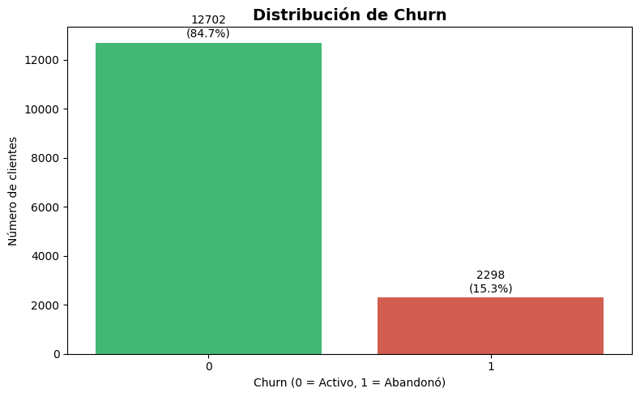

```
Clase mayoritaria: 0 (12,702 casos)
Clase minoritaria: 1 (2,298 casos)
Razón mayoría/minoría: 5.53
⚠️ Existe un desbalance relevante; Accuracy no debería ser la única métrica.

================================================================================
 PERFIL DEMOGRÁFICO DE LA MUESTRA
================================================================================
```

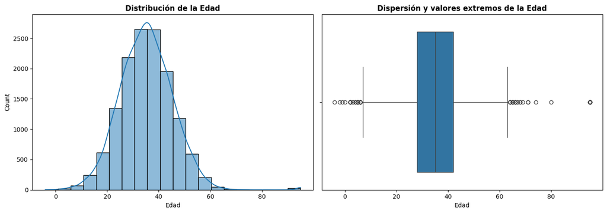

```
count    13800.00
mean        35.20
std         10.33
min         -4.00
25%         28.00
50%         35.00
75%         42.00
max         95.00
Name: age, dtype: float64
```

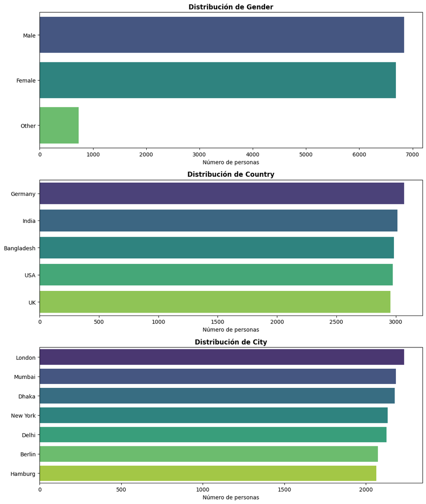

```python
# ============================================================
# PASO 5: ANÁLISIS DE LA VARIABLE OBJETIVO (CHURN)
# ============================================================

target = "churn"

print("\n" + "="*80)
print(" ANÁLISIS DE LA VARIABLE OBJETIVO")
print("="*80)

# Tabla de frecuencias
target_table = df[target].value_counts().to_frame("frecuencia")
target_table["porcentaje"] = (target_table["frecuencia"] / len(df) * 100).round(2)
print(target_table)

# Visualización
plt.figure(figsize=(8, 5))
ax = sns.countplot(data=df, x=target, palette=['#2ecc71', '#e74c3c'])
plt.title("Distribución de Churn", fontsize=14, fontweight="bold")
plt.xlabel("Churn (0 = Activo, 1 = Abandonó)")
plt.ylabel("Número de clientes")

total = len(df)
for container in ax.containers:
    labels = [f"{int(v.get_height())}\n({v.get_height()/total:.1%})" for v in container]
    ax.bar_label(container, labels=labels, padding=3)
plt.tight_layout()
plt.show()

# Cálculo del desbalance
class_counts = df[target].value_counts()
imbalance_ratio = class_counts.max() / class_counts.min()
print(f"\nClase mayoritaria: {class_counts.idxmax()} ({class_counts.max():,} casos)")
print(f"Clase minoritaria: {class_counts.idxmin()} ({class_counts.min():,} casos)")
print(f"Razón mayoría/minoría: {imbalance_ratio:.2f}")

if imbalance_ratio < 1.5:
    print("✅ Las clases están razonablemente balanceadas.")
elif imbalance_ratio < 2:
    print("⚠️ Existe un desbalance moderado.")
else:
    print("⚠️ Existe un desbalance relevante; Accuracy no debería ser la única métrica.")

# ============================================================
# PASO 6: PERFIL DEMOGRÁFICO
# ============================================================

print("\n" + "="*80)
print(" PERFIL DEMOGRÁFICO DE LA MUESTRA")
print("="*80)

# Distribución de edad
fig, axes = plt.subplots(1, 2, figsize=(14, 5))

sns.histplot(data=df, x="age", bins=20, kde=True, ax=axes[0])
axes[0].set_title("Distribución de la Edad", fontweight="bold")
axes[0].set_xlabel("Edad")

sns.boxplot(data=df, x="age", ax=axes[1])
axes[1].set_title("Dispersión y valores extremos de la Edad", fontweight="bold")
axes[1].set_xlabel("Edad")

plt.tight_layout()
plt.show()

print(df["age"].describe().round(2))

# Variables demográficas categóricas
demographic_cols = ["gender", "country", "city"]

fig, axes = plt.subplots(len(demographic_cols), 1, figsize=(11, 13))

for ax, col in zip(axes, demographic_cols):
    order = df[col].value_counts().index
    sns.countplot(data=df, y=col, order=order, ax=ax, palette="viridis")
    ax.set_title(f"Distribución de {col.capitalize()}", fontweight="bold")
    ax.set_xlabel("Número de personas")
    ax.set_ylabel("")

plt.tight_layout()
plt.show()
```

# ANÁLISIS DE COMPORTAMIENTO Y USO (Pasos 7-8)

## Objetivo:

**Analizar cómo se comportan los clientes y cómo varía según el estado de churn.**

### Justificación:

Este análisis responde directamente a la pregunta “¿Qué clientes son más propensos a abandonar?”.

- Analizar variables de comportamiento: visitas, tiempo de sesión, emails, tickets de soporte, retrasos.
- Comparar churners vs no churners mediante boxplots y tablas de resumen.

```
================================================================================
 ANÁLISIS DE COMPORTAMIENTO Y USO
================================================================================

--- Estadísticas descriptivas de variables de comportamiento ---
                       count   mean   std   min    25%    50%    75%    max
total_visits         15000.0  15.00  3.89  3.00  12.00  15.00  18.00  31.00
avg_session_time     15000.0   8.02  2.99  0.01   5.97   7.99  10.06  19.12
pages_per_session    15000.0   4.00  1.48  0.01   2.99   4.00   5.01  10.84
email_open_rate      15000.0   0.50  0.29  0.00   0.24   0.50   0.75   1.00
email_click_rate     15000.0   0.25  0.14  0.00   0.13   0.25   0.38   0.50
support_tickets      15000.0   2.00  1.42  0.00   1.00   2.00   3.00   9.00
delivery_delay_days  15000.0   2.98  1.72  0.00   2.00   3.00   4.00  11.00
```

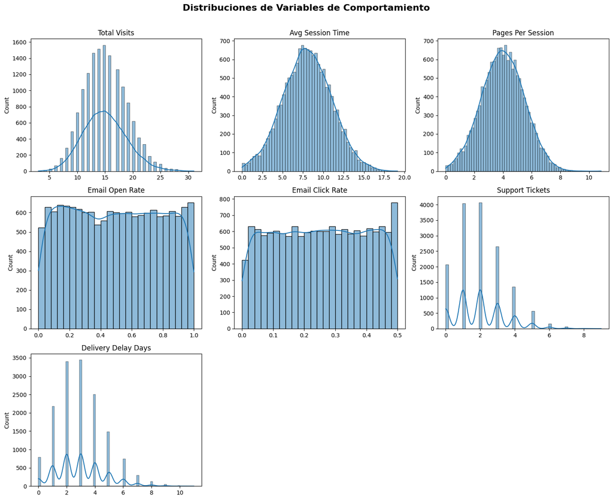

```
================================================================================
 COMPARACIÓN: CHURNERS VS NO CHURNERS
================================================================================
      total_visits        avg_session_time        pages_per_session         \
              mean median             mean median              mean median
churn
0            14.98   15.0             8.01   7.97              4.00    4.0
1            15.12   15.0             8.11   8.21              4.02    4.0

      email_open_rate        email_click_rate        support_tickets         \
                 mean median             mean median            mean median
churn
0                0.50   0.50             0.25   0.25            1.92    2.0
1                0.49   0.49             0.25   0.25            2.42    2.0

      delivery_delay_days
                     mean median
churn
0                    2.98    3.0
1                    2.99    3.0
```

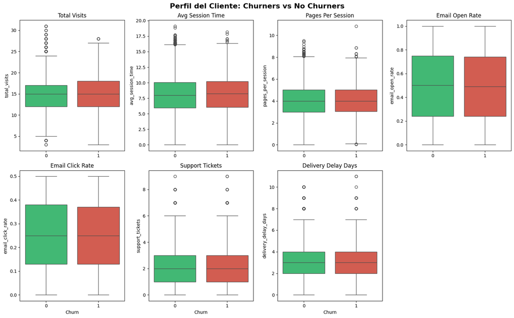

```python
# ============================================================
# PASO 7: ANÁLISIS DE COMPORTAMIENTO Y USO
# ============================================================

print("\n" + "="*80)
print(" ANÁLISIS DE COMPORTAMIENTO Y USO")
print("="*80)

behavior_vars = [
    "total_visits", "avg_session_time", "pages_per_session",
    "email_open_rate", "email_click_rate",
    "support_tickets", "delivery_delay_days"
]

print("\n--- Estadísticas descriptivas de variables de comportamiento ---")
print(df[behavior_vars].describe().T.round(2))

# Distribuciones
fig, axes = plt.subplots(3, 3, figsize=(15, 12))
axes = axes.flatten()

for i, col in enumerate(behavior_vars):
    sns.histplot(data=df, x=col, kde=True, ax=axes[i])
    axes[i].set_title(col.replace("_", " ").title())
    axes[i].set_xlabel("")

for j in range(len(behavior_vars), len(axes)):
    axes[j].axis("off")

plt.suptitle("Distribuciones de Variables de Comportamiento", y=1.01, fontsize=16, fontweight="bold")
plt.tight_layout()
plt.show()

# ============================================================
# PASO 8: COMPARACIÓN CHURNERS VS NO CHURNERS
# ============================================================

print("\n" + "="*80)
print(" COMPARACIÓN: CHURNERS VS NO CHURNERS")
print("="*80)

# Tabla de medias por grupo
group_summary = df.groupby(target)[behavior_vars].agg(["mean", "median"]).round(2)
print(group_summary)

# Boxplots comparativos
fig, axes = plt.subplots(2, 4, figsize=(16, 10))
axes = axes.flatten()

for i, col in enumerate(behavior_vars):
    sns.boxplot(data=df, x=target, y=col, ax=axes[i], palette=['#2ecc71', '#e74c3c'])
    axes[i].set_title(col.replace("_", " ").title())
    axes[i].set_xlabel("Churn" if i >= 4 else "")

for j in range(len(behavior_vars), len(axes)):
    axes[j].axis("off")

plt.suptitle("Perfil del Cliente: Churners vs No Churners", fontsize=16, fontweight="bold")
plt.tight_layout()
plt.show()
```

# ANÁLISIS DE RELACIONES Y CORRELACIONES (Pasos 9-10).

## Objetivo:

**Identificar qué variables están más asociadas con el churn.**

### Justificación:

La identificación de variables correlacionadas con el target es el puente hacia el modelado.

- Calcular la matriz de correlación de Spearman (robusta para datos no normales).
- Generar un heatmap de correlaciones.
- Ranking de asociaciones con churn.

```
================================================================================
 ANÁLISIS DE RELACIONES Y CORRELACIONES
================================================================================
```

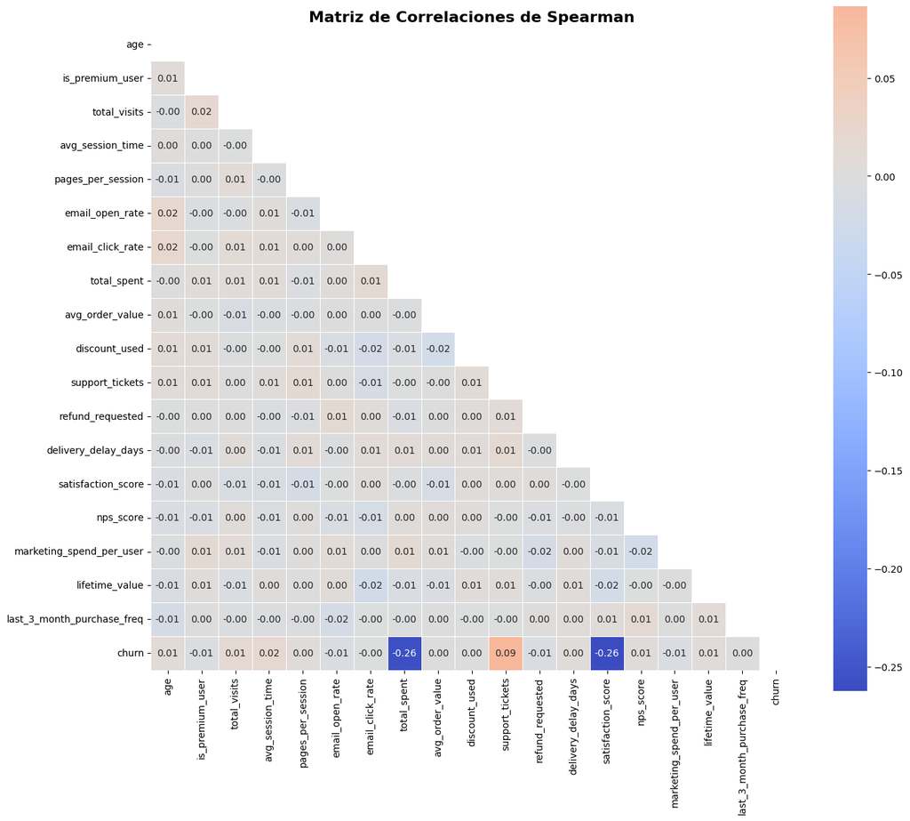

```
--- RANKING DE ASOCIACIONES CON CHURN ---
```

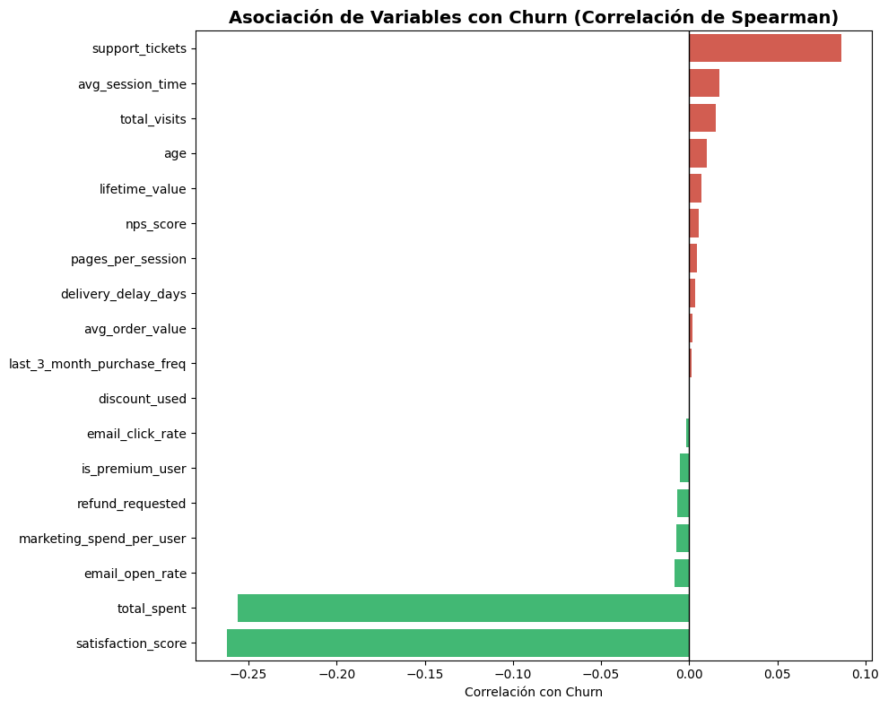

```
Top 5 variables con mayor asociación positiva al churn:
   - support_tickets: ρ = 0.086
   - avg_session_time: ρ = 0.017
   - total_visits: ρ = 0.015
   - age: ρ = 0.010
   - lifetime_value: ρ = 0.007

Top 5 variables con mayor asociación negativa al churn:
   - refund_requested: ρ = -0.007
   - marketing_spend_per_user: ρ = -0.007
   - email_open_rate: ρ = -0.008
   - total_spent: ρ = -0.256
   - satisfaction_score: ρ = -0.262
```

```python
# ============================================================
# PASO 9: MATRIZ DE CORRELACIONES
# ============================================================

print("\n" + "="*80)
print(" ANÁLISIS DE RELACIONES Y CORRELACIONES")
print("="*80)

# Seleccionar variables numéricas relevantes (excluyendo identificadores)
numeric_cols = df.select_dtypes(include=['number']).columns.tolist()
exclude_cols = ['customer_id']
numeric_cols = [c for c in numeric_cols if c not in exclude_cols]

# Matriz de correlación de Spearman
corr_matrix = df[numeric_cols].corr(method='spearman')

# Heatmap
plt.figure(figsize=(14, 12))
mask = np.triu(np.ones_like(corr_matrix, dtype=bool))
sns.heatmap(
    corr_matrix,
    mask=mask,
    annot=True,
    fmt=".2f",
    center=0,
    cmap="coolwarm",
    square=True,
    linewidths=0.5
)
plt.title("Matriz de Correlaciones de Spearman", fontsize=16, fontweight="bold")
plt.tight_layout()
plt.show()

# ============================================================
# PASO 10: RANKING DE ASOCIACIONES CON CHURN
# ============================================================

print("\n--- RANKING DE ASOCIACIONES CON CHURN ---")

# Correlaciones con el target
target_corr = corr_matrix[target].drop(target).sort_values(ascending=False)

plt.figure(figsize=(10, 8))
colors = ['#e74c3c' if v > 0 else '#2ecc71' for v in target_corr.values]
sns.barplot(x=target_corr.values, y=target_corr.index, orient="h", palette=colors)
plt.axvline(0, color="black", linewidth=1)
plt.title("Asociación de Variables con Churn (Correlación de Spearman)", fontsize=14, fontweight="bold")
plt.xlabel("Correlación con Churn")
plt.ylabel("")
plt.tight_layout()
plt.show()

print("\nTop 5 variables con mayor asociación positiva al churn:")
for var, value in target_corr.head(5).items():
    print(f"   - {var}: ρ = {value:.3f}")

print("\nTop 5 variables con mayor asociación negativa al churn:")
for var, value in target_corr.tail(5).items():
    print(f"   - {var}: ρ = {value:.3f}")
```

# Análisis Avanzado de Correlaciones – Detección de Umbrales, Heterogeneidad por Segmentos, Multicolinealidad y Efectos Directos

## Objetivo:

**Ir más allá de la correlación de Spearman estándar para descubrir relaciones ocultas que no son lineales, que varían entre segmentos de clientes o que están enmascaradas por variables confusoras. Esto permite:**

- Identificar puntos de corte críticos (umbrales) en la satisfacción.
- Evaluar si la fuerza de la relación cambia según el nivel de gasto.
- Verificar la ausencia de redundancia entre predictores.
- Aislar el efecto directo de la satisfacción sobre el churn, controlando por el gasto.

### Justificación:

Los resultados del Paso 10 mostraron correlaciones máximas de solo |0.26|, lo que indica que el churn es un fenómeno complejo que probablemente no se comporta de forma lineal. Ignorar esta complejidad llevaría a una ingeniería de características y selección de modelos subóptima.

Esta re‑evaluación avanzada proporciona la base sólida para la preparación de datos y el modelado posterior.

```
================================================================================
 RE-EVALUACIÓN AVANZADA DE CORRELACIONES
================================================================================

--- 1. ANÁLISIS DE UMBRALES ---
Evaluando si existe un punto de corte crítico en la satisfacción.

Tasa de Churn por Puntuación de Satisfacción:
   satisfaction_score     churn
0                 1.0  0.487384
1                 2.0  0.501718
2                 3.0  0.096550
3                 4.0  0.088860
4                 5.0  0.097094
```

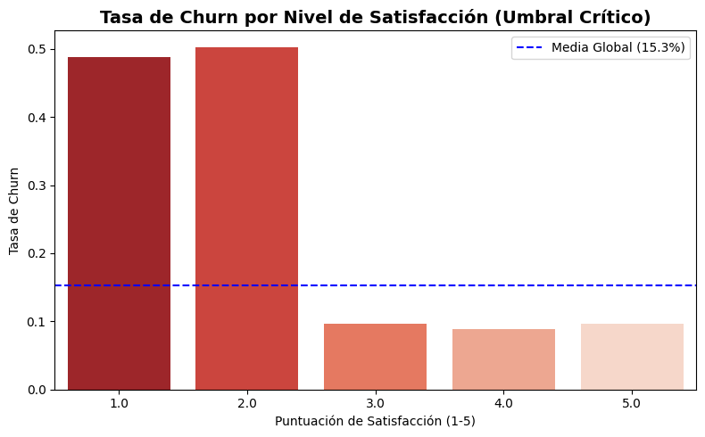

```
--- 2. CORRELACIONES POR SEGMENTO ---
Segmentamos por cuartiles de gasto, excluyendo nulos y creando categoría 'Sin gasto'.

Correlación (satisfacción vs churn) por segmento de gasto:
   Gasto Medio-Alto: ρ = -0.3895183911813972
   Gasto Medio-Bajo: ρ = -0.34751231584684833
   Gasto Bajo: ρ = -0.09623747941892888
   Gasto Sin gasto: ρ = -0.3728131929362084
   Gasto Alto: ρ = -0.37764551231694493

Interpretación: Si las correlaciones son más negativas en segmentos de bajo gasto,
significa que la satisfacción importa más para los clientes que gastan poco.

--- 3. ANÁLISIS DE MULTICOLINEALIDAD ---
Verificando si hay predictores redundantes (correlación > |0.7|).
```

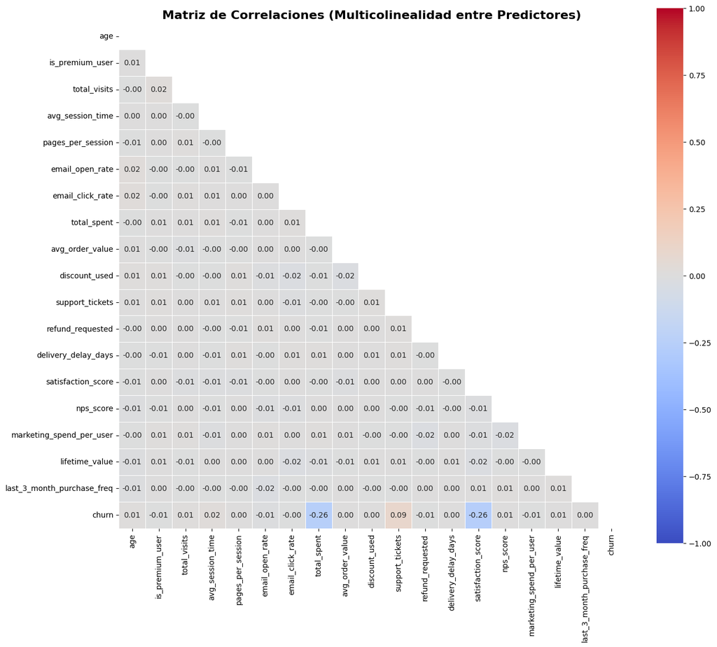

```
✅ No se detectó multicolinealidad severa (>|0.7|).

--- 4. CORRELACIÓN PARCIAL ---
Aislando el efecto directo de la satisfacción, eliminando la influencia del gasto (total_spent).

Correlación bruta (Spearman): ρ = -0.256
Correlación parcial (controlando por total_spent): ρ = -0.297
Diferencia: -0.042
✅ La correlación es robusta al control por 'total_spent'.

================================================================================
 RE-EVALUACIÓN COMPLETADA
================================================================================
```

```python
# ============================================================
# RE-EVALUACIÓN AVANZADA DE CORRELACIONES
# ============================================================
# OBJETIVO: Profundizar en las relaciones débiles encontradas en el Paso 10.
# Buscamos: (1) Umbrales no lineales, (2) Efectos por segmentos,
# (3) Multicolinealidad y (4) Correlación Parcial (eliminando confusores).

import pandas as pd
import numpy as np
import matplotlib.pyplot as plt
import seaborn as sns
from scipy.stats import spearmanr, pearsonr
from sklearn.linear_model import LinearRegression

print("\n" + "="*80)
print(" RE-EVALUACIÓN AVANZADA DE CORRELACIONES")
print("="*80)

# ============================================================
# 1. ANÁLISIS DE UMBRALES (RELACIONES NO LINEALES)
# ============================================================
# Justificación: La correlación de Spearman (-0.26) sugiere una relación débil.
# Sin embargo, podría haber un "punto de quiebre" (threshold) donde el churn
# se dispara. Este análisis agrupa por puntuación de satisfacción y calcula
# la tasa de churn para cada grupo.
print("\n--- 1. ANÁLISIS DE UMBRALES ---")
print("Evaluando si existe un punto de corte crítico en la satisfacción.")

# Agrupar por 'satisfaction_score' y calcular la media de 'churn' (tasa de abandono)
threshold_analysis = df.groupby('satisfaction_score')['churn'].mean().reset_index()
print("\nTasa de Churn por Puntuación de Satisfacción:")
print(threshold_analysis)

# Visualización: Si las barras para 1 y 2 son muy altas vs 3,4,5, tenemos un UMBRAL.
plt.figure(figsize=(8, 5))
sns.barplot(data=threshold_analysis, x='satisfaction_score', y='churn', palette='Reds_r')
plt.axhline(y=0.153, color='blue', linestyle='--', label='Media Global (15.3%)')
plt.title('Tasa de Churn por Nivel de Satisfacción (Umbral Crítico)', fontsize=14, fontweight='bold')
plt.xlabel('Puntuación de Satisfacción (1-5)')
plt.ylabel('Tasa de Churn')
plt.legend()
plt.tight_layout()
plt.show()
# INTERPRETACIÓN ESPERADA: Los scores 1 y 2 tienen tasas ~50%, muy superiores al 15.3% global.
# CONCLUSIÓN: La relación NO es lineal; existe un umbral en satisfacción <= 2.

# ============================================================
# 2. CORRELACIONES POR SEGMENTO (VERSIÓN DEFINITIVA CORREGIDA)
# ============================================================
print("\n--- 2. CORRELACIONES POR SEGMENTO ---")
print("Segmentamos por cuartiles de gasto, excluyendo nulos y creando categoría 'Sin gasto'.")

# 2.1 Crear una copia temporal con la columna de gasto sin nulos
df_temp = df.copy()

# 2.2 Asignar segmento según cuartiles (solo para filas con total_spent no nulo)
# Usamos 'duplicates='drop'' por si hay empates en los límites
df_temp.loc[df_temp['total_spent'].notna(), 'spent_segment'] = pd.qcut(
    df_temp.loc[df_temp['total_spent'].notna(), 'total_spent'],
    q=4,
    labels=['Bajo', 'Medio-Bajo', 'Medio-Alto', 'Alto'],
    duplicates='drop'
)

# 2.3 Asignar categoría especial para los nulos
df_temp['spent_segment'] = df_temp['spent_segment'].cat.add_categories('Sin gasto')
df_temp['spent_segment'].fillna('Sin gasto', inplace=True)

# 2.4 Calcular correlaciones por segmento
correlations_by_segment = {}
segments = df_temp['spent_segment'].unique()

for seg in segments:
    subset = df_temp[df_temp['spent_segment'] == seg]
    # Quedarnos solo con filas sin nulos en satisfacción y churn
    subset_clean = subset.dropna(subset=['satisfaction_score', 'churn'])

    # Verificar condiciones mínimas para calcular correlación
    if len(subset_clean) >= 30 and subset_clean['churn'].nunique() > 1 and subset_clean['satisfaction_score'].nunique() > 1:
        corr = spearmanr(subset_clean['satisfaction_score'], subset_clean['churn'])[0]
        correlations_by_segment[f"Gasto {seg}"] = corr
    else:
        if len(subset_clean) < 30:
            correlations_by_segment[f"Gasto {seg}"] = f"N/A (solo {len(subset_clean)} obs)"
        elif subset_clean['churn'].nunique() <= 1:
            correlations_by_segment[f"Gasto {seg}"] = "N/A (churn constante)"
        elif subset_clean['satisfaction_score'].nunique() <= 1:
            correlations_by_segment[f"Gasto {seg}"] = "N/A (satisfacción constante)"
        else:
            correlations_by_segment[f"Gasto {seg}"] = "N/A (error desconocido)"

print("\nCorrelación (satisfacción vs churn) por segmento de gasto:")
for seg, corr in correlations_by_segment.items():
    print(f"   {seg}: ρ = {corr}")

# 2.5 Interpretación rápida (opcional)
print("\nInterpretación: Si las correlaciones son más negativas en segmentos de bajo gasto,")
print("significa que la satisfacción importa más para los clientes que gastan poco.")

# ============================================================
# 3. ANÁLISIS DE MULTICOLINEALIDAD
# ============================================================
# Justificación: Antes de modelar, debemos asegurarnos de que no haya
# predictores redundantes (correlación > |0.7|). Si los hay, debemos
# eliminar uno de ellos para evitar inestabilidad en los coeficientes.
print("\n--- 3. ANÁLISIS DE MULTICOLINEALIDAD ---")
print("Verificando si hay predictores redundantes (correlación > |0.7|).")

# Asegurar que 'numeric_cols' esté definida (por si acaso no se ejecutó antes)
if 'numeric_cols' not in dir():
    numeric_cols = df.select_dtypes(include=['number']).columns.tolist()
    numeric_cols = [c for c in numeric_cols if c not in ['customer_id', 'churn']]

# Matriz de correlación entre todas las variables numéricas (excluyendo ID y target)
corr_matrix_full = df[numeric_cols].corr(method='spearman')

# Visualización del heatmap
plt.figure(figsize=(14, 12))
mask = np.triu(np.ones_like(corr_matrix_full, dtype=bool))  # Oculta la parte superior para no repetir
sns.heatmap(
    corr_matrix_full,
    mask=mask,
    annot=True,
    fmt=".2f",
    center=0,
    cmap="coolwarm",
    square=True,
    linewidths=0.5,
    vmin=-1, vmax=1
)
plt.title("Matriz de Correlaciones (Multicolinealidad entre Predictores)", fontsize=16, fontweight="bold")
plt.tight_layout()
plt.show()

# Detección automática de pares con alta correlación
high_corr_pairs = []
for i in range(len(corr_matrix_full.columns)):
    for j in range(i+1, len(corr_matrix_full.columns)):
        if abs(corr_matrix_full.iloc[i, j]) > 0.7:
            high_corr_pairs.append({
                "var1": corr_matrix_full.columns[i],
                "var2": corr_matrix_full.columns[j],
                "correlacion": corr_matrix_full.iloc[i, j]
            })

if high_corr_pairs:
    print("\n⚠️ Pares con alta multicolinealidad (>|0.7|):")
    for pair in high_corr_pairs:
        print(f"   {pair['var1']} ↔ {pair['var2']}: ρ = {pair['correlacion']:.3f}")
else:
    print("\n✅ No se detectó multicolinealidad severa (>|0.7|).")
# NOTA: Usted ya obtuvo "No se detectó", así que no hay redundancia grave.

# ============================================================
# 4. CORRELACIÓN PARCIAL (CONTROL POR CONFUSORES)
# ============================================================
# Justificación: La correlación bruta entre satisfacción y churn (-0.256)
# podría estar "diluida" por una tercera variable. Por ejemplo, los clientes
# que gastan más (total_spent) suelen estar más satisfechos y también
# abandonan menos. La correlación parcial elimina el efecto de 'total_spent'
# para ver el efecto DIRECTO de la satisfacción sobre el churn.
print("\n--- 4. CORRELACIÓN PARCIAL ---")
print("Aislando el efecto directo de la satisfacción, eliminando la influencia del gasto (total_spent).")

def partial_corr(df, x, y, control):
    """Calcula la correlación parcial entre x e y, eliminando el efecto de 'control'."""
    # Regresamos x contra control y guardamos los residuos (lo que x no comparte con control)
    X_control = df[[control]].values
    y_x = df[x].values
    y_y = df[y].values

    model_x = LinearRegression().fit(X_control, y_x)
    resid_x = y_x - model_x.predict(X_control)  # Residuos de x

    # Regresamos y contra control y guardamos los residuos
    model_y = LinearRegression().fit(X_control, y_y)
    resid_y = y_y - model_y.predict(X_control)  # Residuos de y

    # La correlación entre los residuos es la correlación PARCIAL
    return pearsonr(resid_x, resid_y)[0]

# Limpiar nulos (necesario para la regresión)
df_clean = df.dropna(subset=['satisfaction_score', 'churn', 'total_spent'])

if len(df_clean) > 0:
    partial_corr_value = partial_corr(df_clean, 'satisfaction_score', 'churn', 'total_spent')
    raw_corr = spearmanr(df_clean['satisfaction_score'], df_clean['churn'])[0]

    print(f"\nCorrelación bruta (Spearman): ρ = {raw_corr:.3f}")
    print(f"Correlación parcial (controlando por total_spent): ρ = {partial_corr_value:.3f}")
    print(f"Diferencia: {partial_corr_value - raw_corr:.3f}")

    # Evaluación del impacto del confusor
    if abs(partial_corr_value - raw_corr) > 0.05:
        print("⚠️ El control por 'total_spent' cambia la correlación. Es un factor de confusión.")
    else:
        print("✅ La correlación es robusta al control por 'total_spent'.")
else:
    print("⚠️ No hay suficientes datos sin nulos para calcular la correlación parcial.")

print("\n" + "="*80)
print(" RE-EVALUACIÓN COMPLETADA")
print("="*80)
```

```python
# ============================================================
# GUARDADO DE COPIA ESTANDARIZADA
# ============================================================
# Guarda el DataFrame con nombres de columnas estandarizados
# en data/raw/ para que el Notebook 02 pueda cargarlo directamente
# sin tener que repetir la estandarización.
# ============================================================

# Verificar que 'df' existe en memoria (por si acaso)
if 'df' not in locals():
    print("⚠️ El DataFrame 'df' no está definido. Asegúrate de haber ejecutado el notebook completo.")
else:
    # Asegurar que la carpeta existe
    os.makedirs(os.path.dirname(config.RAW_DATA_PATH), exist_ok=True)

    # Guardar la copia estandarizada
    df.to_csv(config.RAW_DATA_PATH, index=False)
    print(f"✅ Copia estandarizada guardada en: {config.RAW_DATA_PATH}")
    print(f"   Dimensiones: {df.shape[0]:,} filas, {df.shape[1]} columnas")
    print("   Nota: Este archivo ya tiene los nombres de columnas estandarizados.")
```

```
✅ Copia estandarizada guardada en: c:\Users\Divios\Desktop\MEACD_ML1\S1\sales-marketing-churn-analysis\data\raw\sales_marketing_raw.csv
   Dimensiones: 15,000 filas, 30 columnas
   Nota: Este archivo ya tiene los nombres de columnas estandarizados.
```